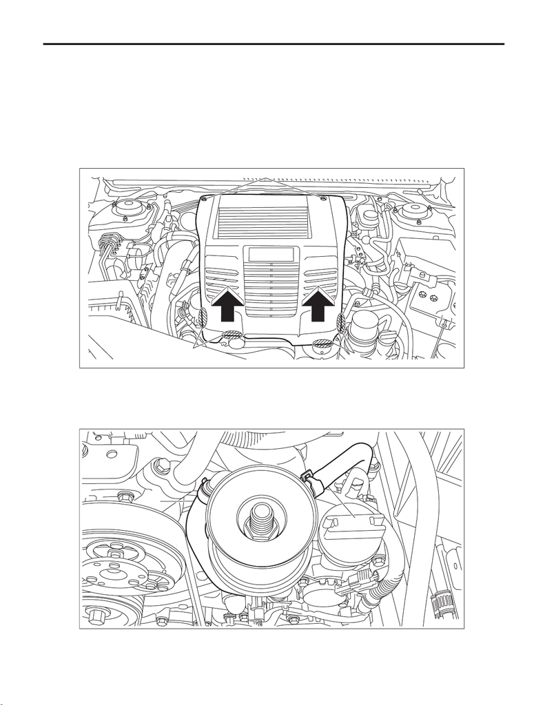

Engine Oil Cooler

LUBRICATION

7. Engine Oil Cooler

A: REMOVAL

CAUTION:

If the engine oil is spilt over exhaust pipe or the under cover, wipe it off with cloth to avoid emission

of smoke or causing a fire.

1) Remove the collector cover.

(1) Remove the clips (A).

(2) Hold the shaded area (B) by hand and carefully pull the RH side (C) upward.

(3) Hold the shaded area (D) by hand and carefully pull the LH side (E) upward.

2) Drain engine coolant. <Ref. to CO(w/o STI)-13, DRAINING OF ENGINE COOLANT, REPLACEMENT,

Engine Coolant.>

3) Remove the engine oil filter. <Ref. to LU(w/o STI)-53, REMOVAL, Engine Oil Filter.>

4) Disconnect the front engine oil cooler hose A (A) and the side engine oil cooler hose A (B) from the engine

oil cooler.

(A)

(B)

(C)

(E)

(D)

(A)

(B)

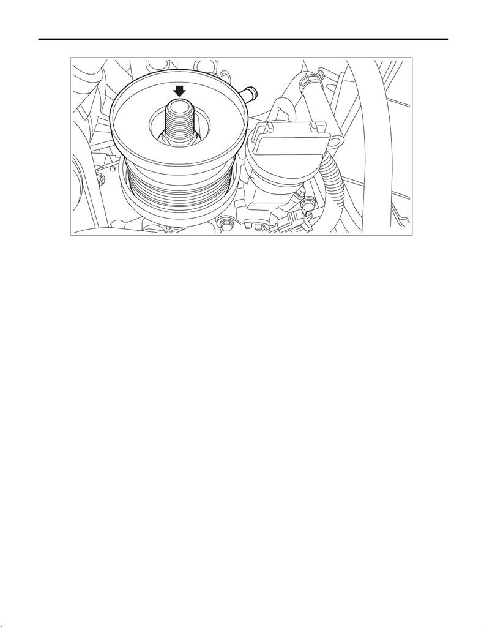

Engine Oil Cooler

LUBRICATION

5) Remove the oil cooler connector and remove the engine oil cooler.

B: INSTALLATION

Install in the reverse order of removal.

NOTE:

• Use a new gasket.

• After installing, check the engine oil level and replenish it if necessary. <Ref. to LU(w/o STI)-10, INSPEC-

TION, Engine Oil.>

Tightening torque:

45 N·m (4.6 kgf-m, 33.2 ft-lb)

C: INSPECTION

1) Check that the engine oil cooler, engine oil cooler pipe, and oil cooler connector do not have deformation,

cracks or damage.

2) Make sure the engine oil cooler hoses are not cracked, damaged or loose.

3) Blow with compressed air to make sure the coolant passages are not clogged.

4) Make sure the mating surfaces of the chain cover do not have damage.